# Predictive Film Revenue

By: Owen Butler

Link for Github: https://ozbutler12.github.io/

```python
from google.colab import drive
drive.mount('/content/drive')
%cd /content/drive/My Drive/Colab Notebooks
```

```
/content/drive/My Drive/Colab Notebooks
```

# Introduction

For this project, I have decided to analyze movies to determine if there is a way to predict different characteristics of the movie. More specifically, I will use a movie's genre, runtime, and rating to predict a movie's gross revenue or box office returns. This information could be very important as it can show what characteristic of a film has the strongest relationship with its gross revenue. As a result, this information is very important for actors as it directly influences how much money they will make, and it also influences movie theaters as it can help them to determine which movies they show and which ones they should not.

These datasets can be used to answer a variety of important questions in the film industry. Some of the questions that the datasets could answer are...

- Can you predict a movie’s success based on its characteristics?
- Which characteristics of a movie has the largest influence on a movies success?
- Is a specific genre of movies more successful than others?

# Collaboration Plan

For this project, I plan on working by myself and using a GitHub repository to store all my information and research. I will also be using Google Drive to help me to stay organized as well. Due to this being an individual project, it will be easy for me to keep track of everything occurring and what needs to be done. I am planning on also using Google Calendar to keep track of project deadlines to ensure that nothing is forgotten about.

# Importing Libraries

```python
import pandas as pd
import numpy as np
import matplotlib.pyplot as plt
import re
import ast
import seaborn as sns
from sklearn.linear_model import LinearRegression
from sklearn.feature_extraction import DictVectorizer
from sklearn.preprocessing import StandardScaler
from sklearn.neighbors import KNeighborsRegressor
from sklearn.pipeline import Pipeline
from sklearn.model_selection import cross_val_score
import warnings
warnings.filterwarnings('ignore')
from IPython.core.display import display, HTML
display(HTML("<style>.container { width:95% !important; }</style>"))
pd.options.display.max_rows = 10000
pd.options.display.width = 1000
```

# Datasets

Dataset 1: [Inflation (1900 - 2022)](https://www.officialdata.org/us/inflation/2022?endYear=1900&amount=1)

This dataset contains the inflation rate for each year from 1900 to 2022. This data will be used to convert the gross revenue into its current value. It stores the conversion rate for each year's currency to the 1900's dollar.

Dataset 2: [IMDB Movies Dataset](https://www.kaggle.com/datasets/harshitshankhdhar/imdb-dataset-of-top-1000-movies-and-tv-shows)

This dataset contains the top 1000 rated movies and tv shows on IMDB, and it has a lot of helpful information for each movie. This includes its release year, certificate (rating), runtime, genre, IMDB rating, meta score, and gross revenue. This data is also going to be used in the prediction algorithm as well.

Dataset 3: [Top 1000 Highest Grossing Movies](https://www.kaggle.com/datasets/sanjeetsinghnaik/top-1000-highest-grossing-movies)

This dataset contains information about the top 1000 grossing movies of all time. It includes information on its domestic revenue, global revenue, rating, runtime, and genre. This dataset will be used to create a prediction model for a movie's gross revenue by using its genre, runtime, and rating.

Dataset 4: [Amazon Prime Movies and TV Shows](https://www.kaggle.com/datasets/shivamb/amazon-prime-movies-and-tv-shows)

This dataset contains more than 10,000 movies and tv shows available on their platform as of mid-2021. It includes its cast, director, ratings, release year, duration, and genre. This dataset will be used to show one possible application of the prediction algorithm, and I will attempt to predict the gross income of movies in this dataset.

```python
boxOffice_df = pd.read_csv(r'Data/Highest Holywood Grossing Movies.csv', encoding='latin-1') #import box office information
IMDB_df = pd.read_csv(r'Data/IMDB.csv') #import IMDB
amazon_df = pd.read_csv(r'Data/amazon.csv') #import amazon
inflation_df = pd.read_csv(r'Data/inflation_data.csv') #import inflation
```

# Extraction, Transform, and Load

While all of these datasets have similar information, they are all organized in different ways. So to solve this problem, I need to reorganize and change the labels of each dataset.

**Inflation**

```python
inflation_df.head()
```

|  | year | amount | inflation rate |
| --- | --- | --- | --- |
| 0 | 1900 | 1.00 | 0.01 |
| 1 | 1901 | 1.01 | 0.01 |
| 2 | 1902 | 1.02 | 0.01 |
| 3 | 1903 | 1.05 | 0.02 |
| 4 | 1904 | 1.06 | 0.01 |

For this dataset, I made a function that converts the gross revenue from the past to what it would be in today's currency. This function works by converting the gross revenue into the 1900 currency, then changing it to 2022 currency from there.

```python
def inflationChange(gross,year):
  year=year-1900
  rate=inflation_df["amount"][year]
  oldValue=gross/rate #Converts to 1900 currency
  newValue=oldValue*inflation_df.loc[122,'amount'] #Converts to 2022 currency
  return newValue
```

**IMDB**

```python
IMDB_df.head()
```

|  | Poster_Link | Series_Title | Released_Year | Certificate | Runtime | Genre | IMDB_Rating | Overview | Meta_score | Director | Star1 | Star2 | Star3 | Star4 | No_of_Votes | Gross |
| --- | --- | --- | --- | --- | --- | --- | --- | --- | --- | --- | --- | --- | --- | --- | --- | --- |
| 0 | https://m.media-amazon.com/images/M/MV5BMDFkYT... | The Shawshank Redemption | 1994 | A | 142 min | Drama | 9.3 | Two imprisoned men bond over a number of years... | 80.0 | Frank Darabont | Tim Robbins | Morgan Freeman | Bob Gunton | William Sadler | 2343110 | 28,341,469 |
| 1 | https://m.media-amazon.com/images/M/MV5BM2MyNj... | The Godfather | 1972 | A | 175 min | Crime, Drama | 9.2 | An organized crime dynasty's aging patriarch t... | 100.0 | Francis Ford Coppola | Marlon Brando | Al Pacino | James Caan | Diane Keaton | 1620367 | 134,966,411 |
| 2 | https://m.media-amazon.com/images/M/MV5BMTMxNT... | The Dark Knight | 2008 | UA | 152 min | Action, Crime, Drama | 9.0 | When the menace known as the Joker wreaks havo... | 84.0 | Christopher Nolan | Christian Bale | Heath Ledger | Aaron Eckhart | Michael Caine | 2303232 | 534,858,444 |
| 3 | https://m.media-amazon.com/images/M/MV5BMWMwMG... | The Godfather: Part II | 1974 | A | 202 min | Crime, Drama | 9.0 | The early life and career of Vito Corleone in ... | 90.0 | Francis Ford Coppola | Al Pacino | Robert De Niro | Robert Duvall | Diane Keaton | 1129952 | 57,300,000 |
| 4 | https://m.media-amazon.com/images/M/MV5BMWU4N2... | 12 Angry Men | 1957 | U | 96 min | Crime, Drama | 9.0 | A jury holdout attempts to prevent a miscarria... | 96.0 | Sidney Lumet | Henry Fonda | Lee J. Cobb | Martin Balsam | John Fiedler | 689845 | 4,360,000 |

For this dataset, several columns are not needed in the analysis. This includes the poster link, IMDB rating, overview, meta score, director, cast, and the number of votes it received. To rectify this, I removed any unnecessary columns and renamed the remaining columns to make them easier to understand.

```python
IMDB_df=IMDB_df.drop(columns = ["Poster_Link","IMDB_Rating","Overview","Meta_score","Star1",	"Star2","Star3","Star4","No_of_Votes"])
IMDB_df = IMDB_df.rename(columns={'Director':'director','Released_Year': 'release_year','Genre':'listed_in','Series_Title':'title','Certificate':'rating',"Runtime":"duration"})
IMDB_df.head()
```

|  | title | release_year | rating | duration | listed_in | director | Gross |
| --- | --- | --- | --- | --- | --- | --- | --- |
| 0 | The Shawshank Redemption | 1994 | A | 142 min | Drama | Frank Darabont | 28,341,469 |
| 1 | The Godfather | 1972 | A | 175 min | Crime, Drama | Francis Ford Coppola | 134,966,411 |
| 2 | The Dark Knight | 2008 | UA | 152 min | Action, Crime, Drama | Christopher Nolan | 534,858,444 |
| 3 | The Godfather: Part II | 1974 | A | 202 min | Crime, Drama | Francis Ford Coppola | 57,300,000 |
| 4 | 12 Angry Men | 1957 | U | 96 min | Crime, Drama | Sidney Lumet | 4,360,000 |

This data is currently using the Central Board of Film Certification. To use this data, I need to convert it to the United States rating system.

```python
IMDB_df["rating"]=IMDB_df["rating"].map({"A": "R","U":"PG","UA":"PG-13","U/A":"PG-13","S":"NC-17"})
```

Also, I need to remove any empty values and the commas from the gross values.

```python
IMDB_df=IMDB_df.dropna()
IMDB_df.Gross = IMDB_df['Gross'].str.replace(',', '') #Removes ,
```

Next, I need to convert the duration and gross revenue into an integer.

```python
IMDB_df['Gross'] = IMDB_df['Gross'].astype(int)
IMDB_df['duration'] = IMDB_df['duration'].str.replace(r' min$', '', regex=True) #Removes the 'min' from the duration
IMDB_df["duration"]=IMDB_df["duration"].astype(int)
```

Lastly, I need to adjust the gross revnue for inflation.

```python
IMDB_df['currentGross']=""
for ind in IMDB_df.index: #Adjusts for inflation
  gross=IMDB_df["Gross"][ind]
  year=IMDB_df["release_year"][ind]
  IMDB_df.loc[ind,"currentGross"]=inflationChange(gross,year)
IMDB_df['currentGross'] = IMDB_df['currentGross'].astype(int)

IMDB_df.head()
```

|  | title | release_year | rating | duration | listed_in | director | Gross | currentGross |
| --- | --- | --- | --- | --- | --- | --- | --- | --- |
| 0 | The Shawshank Redemption | 1994 | R | 142 | Drama | Frank Darabont | 28341469 | 57004269 |
| 1 | The Godfather | 1972 | R | 175 | Crime, Drama | Francis Ford Coppola | 134966411 | 961567924 |
| 2 | The Dark Knight | 2008 | PG-13 | 152 | Action, Crime, Drama | Christopher Nolan | 534858444 | 740412703 |
| 3 | The Godfather: Part II | 1974 | R | 202 | Crime, Drama | Francis Ford Coppola | 57300000 | 346337989 |
| 4 | 12 Angry Men | 1957 | PG | 96 | Crime, Drama | Sidney Lumet | 4360000 | 46176955 |

**Box Office Data**

```python
boxOffice_df.head()
```

|  | Unnamed: 0 | Title | Movie Info | Distributor | Release Date | Domestic Sales (in $) | International Sales (in $) | World Sales (in $) | Genre | Movie Runtime | License |
| --- | --- | --- | --- | --- | --- | --- | --- | --- | --- | --- | --- |
| 0 | 0 | Star Wars: Episode VII - The Force Awakens (2015) | As a new threat to the galaxy rises, Rey, a de... | Walt Disney Studios Motion Pictures | December 16, 2015 | 936662225 | 1132859475 | 2069521700 | ['Action', 'Adventure', 'Sci-Fi'] | 2 hr 18 min | PG-13 |
| 1 | 1 | Avengers: Endgame (2019) | After the devastating events of Avengers: Infi... | Walt Disney Studios Motion Pictures | April 24, 2019 | 858373000 | 1939128328 | 2797501328 | ['Action', 'Adventure', 'Drama', 'Sci-Fi'] | 3 hr 1 min | PG-13 |
| 2 | 2 | Avatar (2009) | A paraplegic Marine dispatched to the moon Pan... | Twentieth Century Fox | December 16, 2009 | 760507625 | 2086738578 | 2847246203 | ['Action', 'Adventure', 'Fantasy', 'Sci-Fi'] | 2 hr 42 min | PG-13 |
| 3 | 3 | Black Panther (2018) | T'Challa, heir to the hidden but advanced king... | Walt Disney Studios Motion Pictures | NaN | 700426566 | 647171407 | 1347597973 | ['Action', 'Adventure', 'Sci-Fi'] | 2 hr 14 min | NaN |
| 4 | 4 | Avengers: Infinity War (2018) | The Avengers and their allies must be willing ... | Walt Disney Studios Motion Pictures | NaN | 678815482 | 1369544272 | 2048359754 | ['Action', 'Adventure', 'Sci-Fi'] | 2 hr 29 min | NaN |

To analyze this data set, I need to make several alterations to it. The first one is that I need to remove any columns that are not needed in my analysis. This includes the first column (Unnamed: 0), Movie Info, Distributor, and domestic and international sales. I also need to remove any movies with missing information and match the column names with the previous dataset.

```python
boxOffice_df=boxOffice_df.drop(columns = ["Unnamed: 0","Movie Info","Distributor","Domestic Sales (in $)","International Sales (in $)"])
boxOffice_df = boxOffice_df.rename(columns={'Title':'title','Release Date':'release_year','World Sales (in $)':'Gross','Genre':'listed_in','Movie Runtime':'duration','License':'rating'})
boxOffice_df=boxOffice_df.dropna()
boxOffice_df.head()
```

|  | title | release_year | Gross | listed_in | duration | rating |
| --- | --- | --- | --- | --- | --- | --- |
| 0 | Star Wars: Episode VII - The Force Awakens (2015) | December 16, 2015 | 2069521700 | ['Action', 'Adventure', 'Sci-Fi'] | 2 hr 18 min | PG-13 |
| 1 | Avengers: Endgame (2019) | April 24, 2019 | 2797501328 | ['Action', 'Adventure', 'Drama', 'Sci-Fi'] | 3 hr 1 min | PG-13 |
| 2 | Avatar (2009) | December 16, 2009 | 2847246203 | ['Action', 'Adventure', 'Fantasy', 'Sci-Fi'] | 2 hr 42 min | PG-13 |
| 6 | Titanic (1997) | December 19, 1997 | 2201647264 | ['Drama', 'Romance'] | 3 hr 14 min | PG-13 |
| 7 | Jurassic World (2015) | June 10, 2015 | 1670516444 | ['Action', 'Adventure', 'Sci-Fi'] | 2 hr 4 min | PG-13 |

Also, I need to reformat the release_year column only to have the year instead of the entire date. Additionally, I need to change the listed_in column to a string instead of an array.

```python
boxOffice_df['release_year'] = boxOffice_df['release_year'].str[-4:] #Makes it the year only
boxOffice_df['listed_in'] = boxOffice_df['listed_in'].str.replace('[', '', regex=True) #Removes [
boxOffice_df['listed_in'] = boxOffice_df['listed_in'].str.replace('\'', '', regex=True) #Removes '
boxOffice_df['listed_in'] = boxOffice_df['listed_in'].str.replace(']', '', regex=True) #Removes ]
boxOffice_df.head()
```

|  | title | release_year | Gross | listed_in | duration | rating |
| --- | --- | --- | --- | --- | --- | --- |
| 0 | Star Wars: Episode VII - The Force Awakens (2015) | 2015 | 2069521700 | Action, Adventure, Sci-Fi | 2 hr 18 min | PG-13 |
| 1 | Avengers: Endgame (2019) | 2019 | 2797501328 | Action, Adventure, Drama, Sci-Fi | 3 hr 1 min | PG-13 |
| 2 | Avatar (2009) | 2009 | 2847246203 | Action, Adventure, Fantasy, Sci-Fi | 2 hr 42 min | PG-13 |
| 6 | Titanic (1997) | 1997 | 2201647264 | Drama, Romance | 3 hr 14 min | PG-13 |
| 7 | Jurassic World (2015) | 2015 | 1670516444 | Action, Adventure, Sci-Fi | 2 hr 4 min | PG-13 |

Lastly, I need to remove the year from the title column and make the duration and release year an integer that shows how long the movie is in minutes. I also converted the gross revenue into the current dollar equivalence.

```python
boxOffice_df['title'] = boxOffice_df['title'].str[:-6] #Removes the year from the title column
```

```python
def durationConvert(time): #Converts the string runtime into an integer
  hour=time[0:time.find('hr')-1]
  minutes=time[time.find('hr')+3:time.find('min')]
  if(hour==""):
    hour=0
  if(minutes==""):
    minutes=0
  runtime = int(float(hour))*60+ int(float(minutes)) #Creates the new integer runtime
  return runtime
for ind in boxOffice_df.index: #Cycles through the dataframe
  boxOffice_df.loc[ind,"duration"]=durationConvert(boxOffice_df["duration"][ind])
boxOffice_df["release_year"]=boxOffice_df["release_year"].astype(int)
boxOffice_df['currentGross']=""
for ind in boxOffice_df.index: #Adjusts for inflation
  gross=boxOffice_df["Gross"][ind]
  year=boxOffice_df["release_year"][ind]
  boxOffice_df.loc[ind,"currentGross"]=inflationChange(gross,year)
boxOffice_df.head()
```

|  | title | release_year | Gross | listed_in | duration | rating | currentGross |
| --- | --- | --- | --- | --- | --- | --- | --- |
| 0 | Star Wars: Episode VII - The Force Awakens | 2015 | 2069521700 | Action, Adventure, Sci-Fi | 138 | PG-13 | 2601935858.114812 |
| 1 | Avengers: Endgame | 2019 | 2797501328 | Action, Adventure, Drama, Sci-Fi | 181 | PG-13 | 3260688144.462549 |
| 2 | Avatar | 2009 | 2847246203 | Action, Adventure, Fantasy, Sci-Fi | 162 | PG-13 | 3955375696.258418 |
| 6 | Titanic | 1997 | 2201647264 | Drama, Romance | 194 | PG-13 | 4087621398.572475 |
| 7 | Jurassic World | 2015 | 1670516444 | Action, Adventure, Sci-Fi | 124 | PG-13 | 2100280773.675407 |

**Amazon Prime**

```python
amazon_df.head()
```

|  | show_id | type | title | director | cast | country | date_added | release_year | rating | duration | listed_in | description |
| --- | --- | --- | --- | --- | --- | --- | --- | --- | --- | --- | --- | --- |
| 0 | s1 | Movie | The Grand Seduction | Don McKellar | Brendan Gleeson, Taylor Kitsch, Gordon Pinsent | Canada | March 30, 2021 | 2014 | NaN | 113 min | Comedy, Drama | A small fishing village must procure a local d... |
| 1 | s2 | Movie | Take Care Good Night | Girish Joshi | Mahesh Manjrekar, Abhay Mahajan, Sachin Khedekar | India | March 30, 2021 | 2018 | 13+ | 110 min | Drama, International | A Metro Family decides to fight a Cyber Crimin... |
| 2 | s3 | Movie | Secrets of Deception | Josh Webber | Tom Sizemore, Lorenzo Lamas, Robert LaSardo, R... | United States | March 30, 2021 | 2017 | NaN | 74 min | Action, Drama, Suspense | After a man discovers his wife is cheating on ... |
| 3 | s4 | Movie | Pink: Staying True | Sonia Anderson | Interviews with: Pink, Adele, Beyoncé, Britney... | United States | March 30, 2021 | 2014 | NaN | 69 min | Documentary | Pink breaks the mold once again, bringing her ... |
| 4 | s5 | Movie | Monster Maker | Giles Foster | Harry Dean Stanton, Kieran O'Brien, George Cos... | United Kingdom | March 30, 2021 | 1989 | NaN | 45 min | Drama, Fantasy | Teenage Matt Banting wants to work with a famo... |

To analyze the ratings of the movies in this dataset, I need to convert the ratings to the American rating system and remove any columns that are not required.

```python
amazon_df=amazon_df.drop(columns = ["show_id","cast","country","date_added","description"], axis=1)
amazon_df["rating"]=amazon_df["rating"].map({
    "All_Ages": "G",
    "ALL":"G",
    "7+":"PG",
    "13+":"PG-13",
    "16+":"PG-13",
    "18+":"R",
    "16":"PG-13",
    "AGES_16":"PG-13",
    "AGES_16_":"PG-13",
    "AGES_18":"R",
    "AGES_18_":"R",
    "NOT_RATE":"UNRATED"
})
amazon_df.head()
```

|  | type | title | director | release_year | rating | duration | listed_in |
| --- | --- | --- | --- | --- | --- | --- | --- |
| 0 | Movie | The Grand Seduction | Don McKellar | 2014 | NaN | 113 min | Comedy, Drama |
| 1 | Movie | Take Care Good Night | Girish Joshi | 2018 | PG-13 | 110 min | Drama, International |
| 2 | Movie | Secrets of Deception | Josh Webber | 2017 | NaN | 74 min | Action, Drama, Suspense |
| 3 | Movie | Pink: Staying True | Sonia Anderson | 2014 | NaN | 69 min | Documentary |
| 4 | Movie | Monster Maker | Giles Foster | 1989 | NaN | 45 min | Drama, Fantasy |

I also need to remove any tv shows from the dataset and any empty values.

```python
amazon_df=amazon_df.dropna()
amazon_df=amazon_df[amazon_df['type']=='Movie']
amazon_df=amazon_df.drop(columns = ["type"])
amazon_df.head()
```

|  | title | director | release_year | rating | duration | listed_in |
| --- | --- | --- | --- | --- | --- | --- |
| 1 | Take Care Good Night | Girish Joshi | 2018 | PG-13 | 110 min | Drama, International |
| 16 | Zoombies | Glenn Miller | 2016 | PG-13 | 87 min | Horror, Science Fiction |
| 25 | Zambezi: Force of Life | Dr. Rudolf Lammers | 2005 | G | 50 min | Documentary |
| 32 | Young Lovers | Ida Lupino | 1949 | R | 86 min | Drama |
| 38 | Yoga with Sound Meditations | Mark Knight | 2016 | G | 9 min | Fitness, Special Interest |

Lastly, I need to convert the duration to an integer of the runtime.

```python
amazon_df['duration'] = amazon_df['duration'].str.replace(r' min$', '', regex=True)
amazon_df["duration"]=amazon_df["duration"].astype(int)
amazon_df.head()
```

|  | title | director | release_year | rating | duration | listed_in |
| --- | --- | --- | --- | --- | --- | --- |
| 1 | Take Care Good Night | Girish Joshi | 2018 | PG-13 | 110 | Drama, International |
| 16 | Zoombies | Glenn Miller | 2016 | PG-13 | 87 | Horror, Science Fiction |
| 25 | Zambezi: Force of Life | Dr. Rudolf Lammers | 2005 | G | 50 | Documentary |
| 32 | Young Lovers | Ida Lupino | 1949 | R | 86 | Drama |
| 38 | Yoga with Sound Meditations | Mark Knight | 2016 | G | 9 | Fitness, Special Interest |

# Merging the Data

To analyze the entirety of the movie industry, I needed to merge my data frames. I decided to combine the box office return and the IMDB datasets to check the relationship between a movie's revenue and its genre, runtime, and rating. Additionally, there are more than 1,000 movies in this new dataset. After merging the data, it leaves me with two data frames, one of the box office returns and the IMDB dataset, and one from Amazon Prime.

```python
movies_df=pd.concat([IMDB_df, boxOffice_df],axis=0)
movies_df['duration']=movies_df['duration'].astype(int)
movies_df['currentGross']=movies_df['currentGross'].astype(int)
movies_df.head()
```

|  | title | release_year | rating | duration | listed_in | director | Gross | currentGross |
| --- | --- | --- | --- | --- | --- | --- | --- | --- |
| 0 | The Shawshank Redemption | 1994 | R | 142 | Drama | Frank Darabont | 28341469 | 57004269 |
| 1 | The Godfather | 1972 | R | 175 | Crime, Drama | Francis Ford Coppola | 134966411 | 961567924 |
| 2 | The Dark Knight | 2008 | PG-13 | 152 | Action, Crime, Drama | Christopher Nolan | 534858444 | 740412703 |
| 3 | The Godfather: Part II | 1974 | R | 202 | Crime, Drama | Francis Ford Coppola | 57300000 | 346337989 |
| 4 | 12 Angry Men | 1957 | PG | 96 | Crime, Drama | Sidney Lumet | 4360000 | 46176955 |

After merging the data, I realized that the genres were stored as a list in the column. So to analyze the data, I need to change the data frame so that each movie only has a single genre that corresponds with it. To do this, I created copies of each film, with each having only one of its corresponding genre. I did this with both data frames.

```python
movies_df["listed_in_new"] = movies_df["listed_in"].apply(lambda x: x.split(","))
exploded_movies = movies_df.explode("listed_in_new").reset_index(drop=True)
exploded_movies['listed_in_new'] = exploded_movies['listed_in_new'].str.replace(" ", "")
exploded_movies.head()
```

|  | title | release_year | rating | duration | listed_in | director | Gross | currentGross | listed_in_new |
| --- | --- | --- | --- | --- | --- | --- | --- | --- | --- |
| 0 | The Shawshank Redemption | 1994 | R | 142 | Drama | Frank Darabont | 28341469 | 57004269 | Drama |
| 1 | The Godfather | 1972 | R | 175 | Crime, Drama | Francis Ford Coppola | 134966411 | 961567924 | Crime |
| 2 | The Godfather | 1972 | R | 175 | Crime, Drama | Francis Ford Coppola | 134966411 | 961567924 | Drama |
| 3 | The Dark Knight | 2008 | PG-13 | 152 | Action, Crime, Drama | Christopher Nolan | 534858444 | 740412703 | Action |
| 4 | The Dark Knight | 2008 | PG-13 | 152 | Action, Crime, Drama | Christopher Nolan | 534858444 | 740412703 | Crime |

```python
amazon_df["listed_in_new"] = amazon_df["listed_in"].apply(lambda x: x.split(","))
exploded_amazon = amazon_df.explode("listed_in_new").reset_index(drop=True)
exploded_amazon['listed_in_new'] = exploded_amazon['listed_in_new'].str.replace(" ", "")
exploded_amazon.head()
```

|  | title | director | release_year | rating | duration | listed_in | listed_in_new |
| --- | --- | --- | --- | --- | --- | --- | --- |
| 0 | Take Care Good Night | Girish Joshi | 2018 | PG-13 | 110 | Drama, International | Drama |
| 1 | Take Care Good Night | Girish Joshi | 2018 | PG-13 | 110 | Drama, International | International |
| 2 | Zoombies | Glenn Miller | 2016 | PG-13 | 87 | Horror, Science Fiction | Horror |
| 3 | Zoombies | Glenn Miller | 2016 | PG-13 | 87 | Horror, Science Fiction | ScienceFiction |
| 4 | Zambezi: Force of Life | Dr. Rudolf Lammers | 2005 | G | 50 | Documentary | Documentary |

# Exploratory Data Analysis

```python
movies_df["currentGross"].describe()
```

```
count    1.287000e+03
mean     4.215479e+08
std      4.266132e+08
min      1.019700e+04
25%      1.446810e+08
50%      3.131492e+08
75%      5.554031e+08
max      4.087621e+09
Name: currentGross, dtype: float64
```

```python
#Spliting the dataframe in half based on gross revenue
Half1=movies_df[movies_df["currentGross"]<= 3.131669e+08]
Half2=movies_df[movies_df["currentGross"]>= 3.131669e+08]
#Dividing it into quarters
Q1=Half1[Half1["currentGross"]< 1.447342e+08]
Q2=Half1[Half1["currentGross"]> 1.447342e+08]
Q3=Half2[Half2["currentGross"]< 5.560239e+08]
Q4=Half2[Half2["currentGross"]> 5.560239e+08]
```

After doing this, I can compare each movie's ratings. Doing this allows me to see which ratings occur more frequently in each quartile of the movie's current gross revenue.

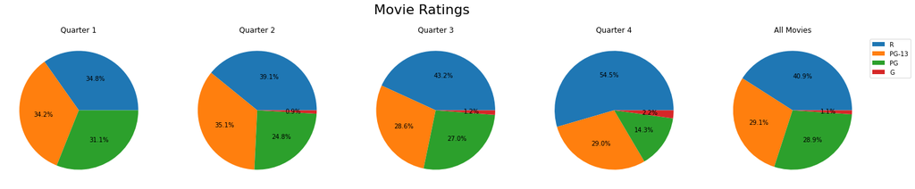

```python
#Counts the frequency of the ratings
ratings=movies_df["rating"].value_counts().iloc[:]
ratings1=Q1["rating"].value_counts().iloc[:]
ratings2=Q2["rating"].value_counts().iloc[:]
ratings3=Q3["rating"].value_counts().iloc[:]
ratings4=Q4["rating"].value_counts().iloc[:]

fig, ax= plt.subplots(1,5, figsize=(25,5))
fig.suptitle('Movie Ratings', fontsize=22)
ax[0].pie(ratings1, autopct='%1.1f%%')#Quarter 1
ax[1].pie(ratings2, autopct='%1.1f%%')#Quarter 2
ax[2].pie(ratings3, autopct='%1.1f%%')#Quarter 3
ax[3].pie(ratings4, autopct='%1.1f%%')#Quarter 4
ax[4].pie(ratings, autopct='%1.1f%%')#All Movies
#Labels
labels=movies_df["rating"].unique()
ax[0].set_title("Quarter 1")
ax[1].set_title("Quarter 2")
ax[2].set_title("Quarter 3")
ax[3].set_title("Quarter 4")
ax[4].set_title("All Movies")
plt.legend(labels,bbox_to_anchor=(1.0, 1.0))
utopct='%1.1f%%'
```

Additionally, I can see if a movie that is more successful and makes more money typically has a longer or shorter duration. To do this, I created a histogram that shows the frequency of a movie's runtime in each quartile of its gross revenue.

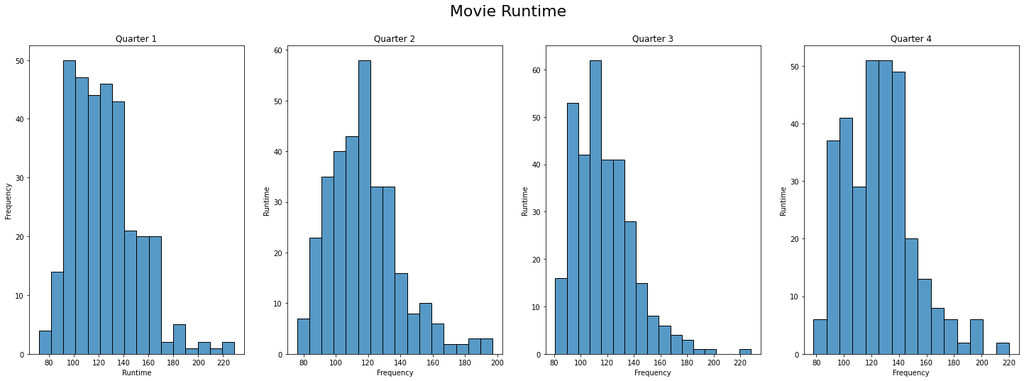

```python
#Creating new dataframes that only contain the duration of each movie
duration=movies_df["duration"]
duration1=Q1["duration"]
duration2=Q2["duration"]
duration3=Q3["duration"]
duration4=Q4["duration"]

fig, ax= plt.subplots(1,4, figsize=(25,8))
fig.suptitle('Movie Runtime', fontsize=22)
#Plotting the histograms
sns.histplot(duration1, ax=ax[0])#Quarter 1
sns.histplot(duration2, ax=ax[1])#Quarter 2
sns.histplot(duration3, ax=ax[2])#Quarter 3
sns.histplot(duration4, ax=ax[3])#Quarter 4
#Labeling
labels=movies_df["rating"].unique()
ax[0].set_title("Quarter 1")
ax[1].set_title("Quarter 2")
ax[2].set_title("Quarter 3")
ax[3].set_title("Quarter 4")

ax[0].set_xlabel("Runtime")
ax[0].set_ylabel("Frequency")
ax[1].set_xlabel("Frequency")
ax[1].set_ylabel("Runtime")
ax[2].set_xlabel("Frequency")
ax[2].set_ylabel("Runtime")
ax[3].set_xlabel("Frequency")
ax[3].set_ylabel("Runtime")
```

To look at how a movie's release year influences its gross revenue, I created scatter plots that display a movie's gross revenue and what year it was released.

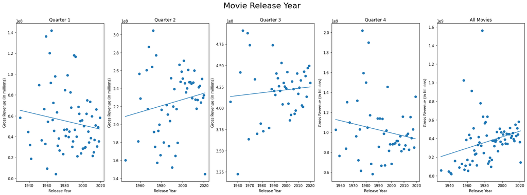

```python
#Grouping the dataframes into gross revenue and release year
release_year=movies_df.groupby("release_year", as_index=False)["currentGross"].mean() #All movies
release_year1=Q1.groupby("release_year", as_index=False)["currentGross"].mean() #Quarter 1
release_year2=Q2.groupby("release_year", as_index=False)["currentGross"].mean() #Quarter 2
release_year3=Q3.groupby("release_year", as_index=False)["currentGross"].mean() #Quarter 3
release_year4=Q4.groupby("release_year", as_index=False)["currentGross"].mean() #Quarter 4
#Creating the lines of best fit for each graph
a1, b1 = np.polyfit(release_year1["release_year"], release_year1["currentGross"], 1)
a2, b2 = np.polyfit(release_year2["release_year"], release_year2["currentGross"], 1)
a3, b3 = np.polyfit(release_year3["release_year"], release_year3["currentGross"], 1)
a4, b4 = np.polyfit(release_year4["release_year"], release_year4["currentGross"], 1)
a, b = np.polyfit(release_year["release_year"], release_year["currentGross"], 1)

fig, ax= plt.subplots(1,5, figsize=(25, 8))
fig.suptitle('Movie Release Year', fontsize=22)
#Plotting the scatter plot
ax[0].scatter(release_year1["release_year"],release_year1["currentGross"])#Quarter 1
ax[1].scatter(release_year2["release_year"],release_year2["currentGross"])#Quarter 2
ax[2].scatter(release_year3["release_year"],release_year3["currentGross"])#Quarter 3
ax[3].scatter(release_year4["release_year"],release_year4["currentGross"])#Quarter 4
ax[4].scatter(release_year["release_year"],release_year["currentGross"])#All movies
#Plotting the lines of best fit
ax[0].plot(release_year1["release_year"], a1*release_year1["release_year"]+b1)
ax[1].plot(release_year2["release_year"], a2*release_year2["release_year"]+b2)
ax[2].plot(release_year3["release_year"], a3*release_year3["release_year"]+b3)
ax[3].plot(release_year4["release_year"], a4*release_year4["release_year"]+b4)
ax[4].plot(release_year["release_year"], a*release_year["release_year"]+b)
#Labels
ax[0].set_title("Quarter 1")
ax[1].set_title("Quarter 2")
ax[2].set_title("Quarter 3")
ax[3].set_title("Quarter 4")
ax[4].set_title("All Movies")

ax[0].set_xlabel("Release Year")
ax[0].set_ylabel("Gross Revenue (in millions)")
ax[1].set_xlabel("Release Year")
ax[1].set_ylabel("Gross Revenue (in millions)")
ax[2].set_xlabel("Release Year")
ax[2].set_ylabel("Gross Revenue (in millions)")
ax[3].set_xlabel("Release Year")
ax[3].set_ylabel("Gross Revenue (in billions)")
ax[4].set_xlabel("Release Year")
ax[4].set_ylabel("Gross Revenue (in billions)")
```

This graph shows that a movie's release year has minimal impact on a movie's box office performance. However, it does show that as the release year increases, there is an increase in the average box office performance each year.

To analyze a movie's genre's impact on its revenue, I created a pie chart that shows the frequency of each of the five most popular genres. These genres include drama, action, adventure, comedy, and thriller.

```python
#Creates a new dataframe storing movies with only the 5 most popular genres
exploded_movies_new = exploded_movies[exploded_movies['listed_in_new'].isin(exploded_movies['listed_in_new'].value_counts()[:5].index.tolist())]
#Spliting the dataframe in half based on gross revenue
Half1=exploded_movies_new[exploded_movies_new["currentGross"]<= 3.131669e+08]
Half2=exploded_movies_new[exploded_movies_new["currentGross"]>= 3.131669e+08]
#Dividing it into quarters
eQ1=Half1[Half1["currentGross"]< 1.447342e+08]
eQ2=Half1[Half1["currentGross"]> 1.447342e+08]
eQ3=Half2[Half2["currentGross"]< 5.560239e+08]
eQ4=Half2[Half2["currentGross"]> 5.560239e+08]
```

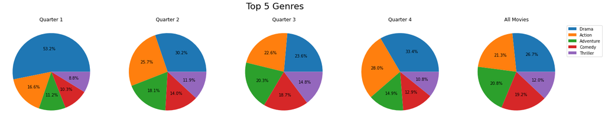

```python
fig, ax= plt.subplots(1,5, figsize=(25,5))
fig.suptitle('Top 5 Genres', fontsize=22)
ax[0].pie(eQ1["listed_in_new"].value_counts().iloc[:], autopct='%1.1f%%') #Quarter 1
ax[1].pie(eQ2["listed_in_new"].value_counts().iloc[:], autopct='%1.1f%%') #Quarter 2
ax[2].pie(eQ3["listed_in_new"].value_counts().iloc[:], autopct='%1.1f%%') #Quarter 3
ax[3].pie(eQ4["listed_in_new"].value_counts().iloc[:], autopct='%1.1f%%') #Quarter 4
ax[4].pie(exploded_movies_new["listed_in_new"].value_counts().iloc[:], autopct='%1.1f%%') #All movies
labels=exploded_movies_new["listed_in_new"].unique()
#Labels
ax[0].set_title("Quarter 1")
ax[1].set_title("Quarter 2")
ax[2].set_title("Quarter 3")
ax[3].set_title("Quarter 4")
ax[4].set_title("All Movies")
plt.legend(labels,bbox_to_anchor=(1.0, 1.0))
autopct='%1.1f%%'
```

```python
#Creates a new dataframe storing movies with only the 10 most popular directors
movies_new = movies_df[movies_df['director'].isin(movies_df['director'].value_counts()[:10].index.tolist())]
#Spliting the dataframe in half based on gross revenue
Half1=movies_new[movies_new["currentGross"]<= 3.131669e+08]
Half2=movies_new[movies_new["currentGross"]>= 3.131669e+08]
#Dividing it into quarters
dQ1=Half1[Half1["currentGross"]< 1.447342e+08]
dQ2=Half1[Half1["currentGross"]> 1.447342e+08]
dQ3=Half2[Half2["currentGross"]< 5.560239e+08]
dQ4=Half2[Half2["currentGross"]> 5.560239e+08]
```

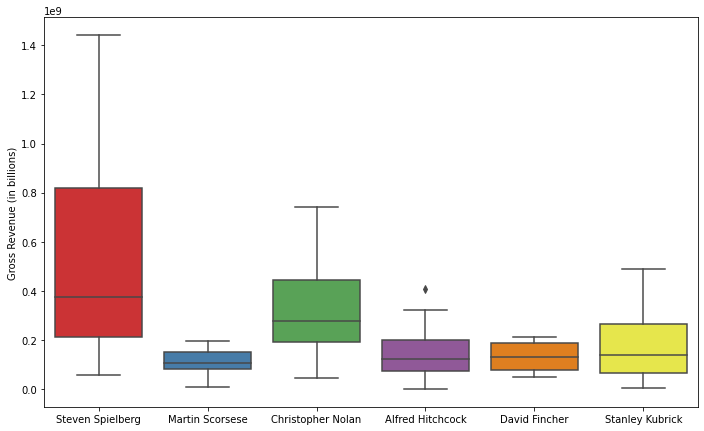

```python
fig, ax= plt.subplots(1,1, figsize=(10,6))
Spielberg=movies_df[movies_df['director']=='Steven Spielberg'] #Spielberg's Movies
Scorsese=movies_df[movies_df['director']=='Martin Scorsese'] #Scorsese's Movies
Nolan=movies_df[movies_df['director']=='Christopher Nolan'] #Nolan's Movies
Hitchcock=movies_df[movies_df['director']=='Alfred Hitchcock'] #Hitchcock's Movies
Fincher=movies_df[movies_df['director']=='David Fincher'] #Fincher's Movies
Kubrick=movies_df[movies_df['director']=='Stanley Kubrick'] #Kubrick's Movies

#Merging the new data frames
PopularDirector = pd.DataFrame({'Steven Spielberg': Spielberg['currentGross'],
                             'Martin Scorsese': Scorsese['currentGross'],
                             'Christopher Nolan': Nolan['currentGross'],
                             'Alfred Hitchcock': Hitchcock['currentGross'],
                             'David Fincher': Fincher['currentGross'],
                             'Stanley Kubrick':Kubrick['currentGross']})
ax.set_ylabel("Gross Revenue (in billions)")
fig.tight_layout()
sns.boxplot(data=PopularDirector, palette='Set1', ax=ax) #Displaying the graph
```

This graph shows that a movie's director significantly impacts a movie's gross revenue. Interestingly, Steven Spielberg's films make signifanctly more money on average than the other directors. For example, only 25% of Steven Spielberg's movies make less money than the most successful movies by Martin Scorsese.

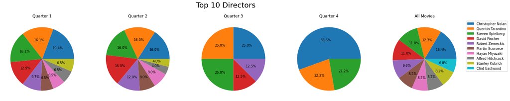

```python
fig, ax= plt.subplots(1,5, figsize=(25,5))
fig.suptitle('Top 10 Directors', fontsize=22)
#Creates five pie charts
ax[0].pie(dQ1["director"].value_counts().iloc[:], autopct='%1.1f%%') #Quarter 1
ax[1].pie(dQ2["director"].value_counts().iloc[:], autopct='%1.1f%%') #Quarter 2
ax[2].pie(dQ3["director"].value_counts().iloc[:], autopct='%1.1f%%') #Quarter 3
ax[3].pie(dQ4["director"].value_counts().iloc[:], autopct='%1.1f%%') #Quarter 4
ax[4].pie(movies_new["director"].value_counts().iloc[:], autopct='%1.1f%%') #All movies
#Labeling the graph
labels=movies_new["director"].unique()
ax[0].set_title("Quarter 1")
ax[1].set_title("Quarter 2")
ax[2].set_title("Quarter 3")
ax[3].set_title("Quarter 4")
ax[4].set_title("All Movies")
plt.legend(labels,bbox_to_anchor=(1.0, 1.0))
utopct='%1.1f%%' #Adds percentages to each part of the circle
```

Lastly, I created a heatmap showing how strong the correlation is between a movie's gross revenue, release year, duration, director, rating, and genre.

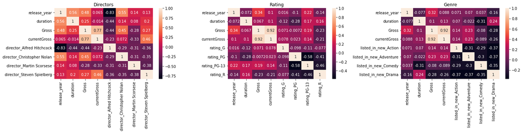

```python
#Creating the correlation for the top 4 directors
director_exploded_movies= exploded_movies[exploded_movies['director'].isin(exploded_movies['director'].value_counts()[:4].index.tolist())]
director_exploded_movies=director_exploded_movies.drop(columns = ['title','listed_in','listed_in_new','rating'])
director_exploded_movies=pd.get_dummies(director_exploded_movies)
director_exploded_movies=director_exploded_movies.corr()
#Creating the correlation for the ratings
rating_exploded_movies=exploded_movies.drop(columns = ['title','listed_in','listed_in_new','director'])
rating_exploded_movies=pd.get_dummies(rating_exploded_movies)
rating_exploded_movies=rating_exploded_movies.corr()
#Creating the correlation for top 4 genres
genre_exploded_movies= exploded_movies[exploded_movies['listed_in_new'].isin(exploded_movies['listed_in_new'].value_counts()[:4].index.tolist())]
genre_exploded_movies=genre_exploded_movies.drop(columns = ['title','listed_in','director','rating'])
genre_exploded_movies=pd.get_dummies(genre_exploded_movies)
genre_exploded_movies=genre_exploded_movies.corr()
#Creating the heatmap
fig, ax =plt.subplots(1,3, figsize=(20,5))
sns.heatmap(director_exploded_movies, annot=True,ax=ax[0])
sns.heatmap(rating_exploded_movies, annot=True, ax=ax[1])
sns.heatmap(genre_exploded_movies, annot=True, ax=ax[2])
fig.tight_layout()
ax[0].set_title("Directors")
ax[1].set_title("Rating")
ax[2].set_title("Genre")
```

# Prediction Model

The information above shows a relationship between a movie's rating, genre, release year, runtime, and gross revenue. As a result, it is possible to attempt to create a model that can predict a movie's gross income with these characteristics. To do this, I will use a K Nearest Neighbors function. By using this model, I can attempt to predict a movie's gross revenue by comparing to movies with similar characteristics.

```python
exploded_movies=exploded_movies.dropna()
# Define the features.
features = ["duration", "release_year","director","rating","listed_in_new"]
# Define the training data.
X_train_dict = exploded_movies[features].to_dict(orient="records")
X_dict = exploded_movies[features].to_dict(orient="records")
y=exploded_movies["currentGross"]
# Dummy encoding
vec = DictVectorizer(sparse=False)
vec.fit(X_train_dict)
X_train = vec.transform(X_train_dict)
# Standardization
scaler = StandardScaler()
scaler.fit(X_train)
model = KNeighborsRegressor(n_neighbors=20)
pipeline = Pipeline([
    ("scaler", scaler),
    ("model", model)
])
cross_val_score(pipeline, X_train, y,
                cv=15, scoring="neg_mean_absolute_error")
# calculates estimate of test error based on 15-fold cross validation
def get_cv_error(k):
    model = KNeighborsRegressor(n_neighbors=k)
    pipeline = Pipeline([("vectorizer", vec), ("scaler", scaler), ("fit", model)])
    mae = np.absolute(-cross_val_score(
        pipeline, X_dict, y,
        cv=15, scoring="neg_mean_absolute_error"
    )).mean()
    return mae
ks = pd.Series(range(1, 51))
ks.index = range(1, 51)
ax = ks.apply(get_cv_error)
ax.argmin()
```

```
2
```

After this, I created a function to forecast a movie's current gross revenue by using its duration, release year, rating, genre, and director.

```python
def prediction(duration, release_year, rating, listed_in_new, director):
  # Define the features.
  features = ["duration", "release_year","director","rating","listed_in_new"]
  # Define the training data.
  X_train_dict = exploded_movies[features].to_dict(orient="records")
  X_dict = exploded_movies[features].to_dict(orient="records")
  y=exploded_movies["currentGross"]
  X_new_dict = [{
      "duration":duration,
      "release_year":release_year,
      "rating":rating,
      "listed_in_new":listed_in_new,
      "director":director
  }]
  y_train = exploded_movies["currentGross"]

  # Dummy encoding
  vec = DictVectorizer(sparse=False)
  vec.fit(X_train_dict)
  X_train = vec.transform(X_train_dict)
  X_new = vec.transform(X_new_dict)

  # Standardization
  scaler = StandardScaler()
  scaler.fit(X_train)
  X_train_sc = scaler.transform(X_train)
  X_new_sc = scaler.transform(X_new)

  # K-Nearest Neighbors Model
  model = KNeighborsRegressor(n_neighbors=2)
  model.fit(X_train_sc, y_train)
  x=model.predict(X_new_sc)
  revenue=x[0]
  return revenue
```

For example, here is the predicted gross revenue for The Dark Knight.

```python
print(prediction(152, 2008, 'PG-13', 'Action', 'Christopher Nolan'))
```

```
570140931.5
```

# Application

Now that I can estimate a movie's gross revenue, there are many possible applications of it. One of these potential applications is to project the gross revenue of movies for Amazon Prime.

For example, I organized the first 100 movies in the amazon dataset from highest projected revenue to lowest.

```python
exploded_amazon["currentGross"]=0 #Makes a new column called currentGross and sets all values equal to 0
for ind in range(100): #Loops through the first 100 movies
  duration=exploded_amazon["duration"][ind]
  release_year=exploded_amazon["release_year"][ind]
  rating=exploded_amazon["rating"][ind]
  listed_in_new=exploded_amazon["listed_in_new"][ind]
  director=exploded_amazon["director"][ind]
  exploded_amazon.loc[ind,"currentGross"]=prediction(duration, release_year, rating, listed_in_new, director)
exploded_amazon["currentGross"]=exploded_amazon["currentGross"].astype(int)
```

After this, I am able to show which 5 movies have the highest revenue.

```python
exploded_amazon.sort_values(by=['currentGross'], ascending=False).head()
```

|  | title | director | release_year | rating | duration | listed_in | listed_in_new | currentGross |
| --- | --- | --- | --- | --- | --- | --- | --- | --- |
| 30 | Yellowneck | R. John Hugh | 1955 | R | 84 | Action, Military and War, Western | MilitaryandWar | 1127559762 |
| 95 | Western Gold | Howard Bretherton | 1937 | R | 56 | Military and War, Western | MilitaryandWar | 1127559762 |
| 91 | What Price Crime | Albert Herman | 1935 | R | 65 | Suspense | Suspense | 1127559762 |
| 40 | Women of Valor | Buzz Kulik | 1986 | PG-13 | 95 | Action, Drama | Action | 821961324 |
| 87 | When the Lights Go On Again | William K. Howard | 1944 | PG-13 | 103 | Drama, Military and War | MilitaryandWar | 740089392 |

# Conclusion

Despite this algorithm taking many factors into account, there are several factors that this model needs to consider, which hinder its accuracy. This includes the movie's cast, the public demand for it, and any elements outside of the film itself that influence its gross revenue. This is shown through the model only having an accuracy of .522, which is fairly low.

```python
X_train_sc = scaler.transform(X_train)
model = KNeighborsRegressor(n_neighbors=2)
model.fit(X_train_sc, y)
y_train_pred=model.predict(X_train_sc)
accuracy = (y_train_pred == y).mean()
accuracy
```

```
0.5224839400428265
```